# CHU_H Final Project Step Two Data Exploration

These are the libraries we are going to use for this step

```r
library(GGally)
```

Before we do any data shaping, we may want to explore our data to get a good sense of what is going on so when we are constructing our model later we can keep in mind that there may or may not be underlying issues with our data.

```r
# Loading the CSV file as a dataframe
april.beatmaps.csv <- read.csv(file = "mostRecent500BeatmapStatisticApril.csv", header = TRUE)
april.beatmaps.dataframe <- as.data.frame(april.beatmaps.csv)
```

To make sure popularity is evaluated fairly, we are going to make a derived column named “playcount_per_day” which is calculated by the beatmap’s playcount divided by the days since it has been approved

```r
data.collected.date <- as.Date("4/15/2018",format='%m/%d/%Y')
date.diff <- data.collected.date - as.Date(april.beatmaps.dataframe$approved_date)
date.diff.as.numeric <- as.numeric(date.diff)
playcount_per_day <- april.beatmaps.dataframe$playcount / date.diff.as.numeric
april.beatmaps.dataframe <- data.frame(april.beatmaps.dataframe,playcount_per_day)
april.beatmaps.dataframe
```

| beatmapset_id | beatmap_id | approved | total_length | hit_length | version | file_md5 | diff_size | diff_overall | diff_approach | diff_drain | mode | approved_date | last_update | artist | title | creator | bpm | source | tags | genre_id | language_id | favourite_count | playcount | passcount | max_combo | difficultyrating | playcount_per_day |
| --- | --- | --- | --- | --- | --- | --- | --- | --- | --- | --- | --- | --- | --- | --- | --- | --- | --- | --- | --- | --- | --- | --- | --- | --- | --- | --- | --- |
| 477006 | 1018937 | 1 | 87 | 84 | Expert | 7f1be0968291b3f4dbc8abbe518e3738 | 4.5 | 9.0 | 9.0 | 6.0 | 0 | 2018-04-01 06:20:10 | 2018-03-23 09:03:16 | IU | Nae Kkumeun Patissiere | Sonnyc | 172.000 |  | opening op1 yumeiro pâtissière | 3 | 6 | 27 | 10368 | 1116 | 436 | 5.267045 | 740.57143 |
| 477006 | 1019069 | 1 | 85 | 81 | Easy | 03d3578687cfc2626f5a70e916d085ca | 3.0 | 2.0 | 3.0 | 2.0 | 0 | 2018-04-01 06:20:10 | 2018-03-23 09:03:16 | IU | Nae Kkumeun Patissiere | Sonnyc | 172.000 |  | opening op1 yumeiro pâtissière | 3 | 6 | 27 | 3393 | 1530 | 235 | 1.368581 | 242.35714 |
| 477006 | 1019973 | 1 | 87 | 84 | Insane | 6cc9ce174afd6c489d9b77a9a783f2a6 | 4.3 | 8.0 | 8.0 | 6.0 | 0 | 2018-04-01 06:20:10 | 2018-03-23 09:03:16 | IU | Nae Kkumeun Patissiere | Sonnyc | 172.000 |  | opening op1 yumeiro pâtissière | 3 | 6 | 27 | 7128 | 477 | 400 | 4.213146 | 509.14286 |
| 477006 | 1019974 | 1 | 87 | 84 | Normal | af0826172064527d428080e6cbe082bf | 4.0 | 4.0 | 5.0 | 3.0 | 0 | 2018-04-01 06:20:10 | 2018-03-23 09:03:16 | IU | Nae Kkumeun Patissiere | Sonnyc | 172.000 |  | opening op1 yumeiro pâtissière | 3 | 6 | 27 | 3258 | 1287 | 276 | 1.885514 | 232.71429 |
| 477006 | 1020830 | 1 | 87 | 84 | Hard | 022ae3f0afad443a07ed9baa03c42d1c | 4.0 | 6.0 | 7.0 | 5.0 | 0 | 2018-04-01 06:20:10 | 2018-03-23 09:03:16 | IU | Nae Kkumeun Patissiere | Sonnyc | 172.000 |  | opening op1 yumeiro pâtissière | 3 | 6 | 27 | 8766 | 2268 | 342 | 3.024783 | 626.14286 |
| 722797 | 1525815 | 1 | 85 | 80 | Easy | d950ed076831c31e9410f328cdf3b0f4 | 2.5 | 3.0 | 3.0 | 3.0 | 0 | 2018-04-01 06:40:33 | 2018-03-23 05:07:16 | Saratoga(CV: Sumire Uesaka) | Souzetsu Gekkou | Yasaija 714 | 180.000 |  | azur lane kalibe asuka_- lasse garden | 2 | 3 | 72 | 5841 | 2484 | 236 | 1.511059 | 417.21429 |
| 722797 | 1525816 | 1 | 86 | 81 | Hard | 8642dc10cf47ffbee60db8cef6d3ae45 | 4.0 | 6.0 | 8.0 | 5.0 | 0 | 2018-04-01 06:40:33 | 2018-03-23 05:07:16 | Saratoga(CV: Sumire Uesaka) | Souzetsu Gekkou | Yasaija 714 | 180.000 |  | azur lane kalibe asuka_- lasse garden | 2 | 3 | 72 | 18207 | 5562 | 431 | 3.127344 | 1300.50000 |
| 722797 | 1525817 | 1 | 86 | 85 | Asuka_-'s Insane | de299436b3f2e1ad4b8de9aaad9d1fb9 | 3.8 | 7.0 | 9.0 | 6.0 | 0 | 2018-04-01 06:40:33 | 2018-03-23 05:07:16 | Saratoga(CV: Sumire Uesaka) | Souzetsu Gekkou | Yasaija 714 | 180.000 |  | azur lane kalibe asuka_- lasse garden | 2 | 3 | 72 | 10917 | 1350 | 486 | 4.989524 | 779.78571 |
| 722797 | 1525818 | 1 | 85 | 80 | Normal | 50d21cd33a1aad76446c4270e9208dc1 | 3.0 | 4.0 | 5.0 | 4.0 | 0 | 2018-04-01 06:40:33 | 2018-03-23 05:07:16 | Saratoga(CV: Sumire Uesaka) | Souzetsu Gekkou | Yasaija 714 | 180.000 |  | azur lane kalibe asuka_- lasse garden | 2 | 3 | 72 | 9216 | 4257 | 292 | 2.136102 | 658.28571 |
| 722797 | 1526255 | 1 | 86 | 82 | Insane | ff3641bf31d8ab348c8076a22855efc7 | 4.0 | 7.0 | 9.0 | 6.0 | 0 | 2018-04-01 06:40:33 | 2018-03-23 05:07:16 | Saratoga(CV: Sumire Uesaka) | Souzetsu Gekkou | Yasaija 714 | 180.000 |  | azur lane kalibe asuka_- lasse garden | 2 | 3 | 72 | 23571 | 3168 | 489 | 4.509651 | 1683.64286 |

[output cut: 490 more lines]

Some basic statistics:

```r
mean.total.length <- mean(april.beatmaps.dataframe$total_length)
summary(april.beatmaps.dataframe)
```

```
 beatmapset_id      beatmap_id         approved     total_length     hit_length        version                                file_md5
 Min.   :147210   Min.   : 364532   Min.   :1.00   Min.   : 13.0   Min.   : 12.0   Normal  : 47   019233f177578d8a66f59ef97d22e4e1:  1
 1st Qu.:594067   1st Qu.:1393960   1st Qu.:1.00   1st Qu.: 89.0   1st Qu.: 86.0   Hard    : 34   01b84ba9bc46c7de3c25536522c739d2:  1
 Median :695009   Median :1506551   Median :1.00   Median :115.0   Median :111.5   Easy    : 31   01c5ea77fd37c7600b355ccf0544af97:  1
 Mean   :654181   Mean   :1429140   Mean   :1.63   Mean   :141.9   Mean   :133.6   Insane  : 27   022ae3f0afad443a07ed9baa03c42d1c:  1
 3rd Qu.:728523   3rd Qu.:1558306   3rd Qu.:3.00   3rd Qu.:196.2   3rd Qu.:180.2   Extra   : 11   0329ca26686210cbb55a39b470b54026:  1
 Max.   :762232   Max.   :1603225   Max.   :4.00   Max.   :380.0   Max.   :362.0   Advanced:  6   0381f6ec08b972d3353b42724ec3f7e0:  1
                                                                                   (Other) :344   (Other)                         :494
   diff_size      diff_overall    diff_approach      diff_drain         mode               approved_date              last_update
 Min.   :2.000   Min.   : 1.000   Min.   : 1.000   Min.   :2.000   Min.   :0   2018-04-02 13:39:58: 35   2018-03-24 16:36:00: 15
 1st Qu.:3.500   1st Qu.: 4.000   1st Qu.: 5.000   1st Qu.:4.000   1st Qu.:0   2018-04-02 11:00:14: 15   2018-04-11 06:32:28: 12
 Median :4.000   Median : 7.000   Median : 8.000   Median :5.000   Median :0   2018-04-11 09:48:29: 12   2018-03-28 06:31:19: 10
 Mean   :3.742   Mean   : 6.324   Mean   : 7.308   Mean   :4.852   Mean   :0   2018-04-07 09:00:54: 10   2018-04-09 07:12:58: 10
 3rd Qu.:4.000   3rd Qu.: 8.000   3rd Qu.: 9.025   3rd Qu.:6.000   3rd Qu.:0   2018-04-10 13:23:01: 10   2017-07-17 19:45:39:  9
 Max.   :7.000   Max.   :10.000   Max.   :10.000   Max.   :8.000   Max.   :0   2018-04-01 06:40:33:  9   2018-03-23 05:07:16:  9
                                                                               (Other)            :409   (Other)            :435
                              artist                title            creator         bpm
 Camellia                        : 16   Chirality      : 15   Sotarks    : 19   Min.   : 73.0
 Tanya Degurechaff (CV: Yuki Aoi): 15   Los! Los! Los! : 15   Kroytz     : 15   1st Qu.:146.0
 Memme                           : 12   Amatsu Kitsune : 12   Kyuukai    : 15   Median :170.0
 *namirin                        : 10   Pandemonium    : 12   Suzuki_1112: 15   Mean   :167.2
 Kano                            : 10   Sakura no Zenya: 10   Delis      : 13   3rd Qu.:190.0
 jioyi                           :  9   Platinum       :  9   sdafsf     : 12   Max.   :259.0
 (Other)                         :428   (Other)        :427   (Other)    :411
                                              source
                                                 :128
 SOUND VOLTEX III GRAVITY WARS                   : 16
 幼女戦記                : 15
 BMS                                             : 15
 REFLEC BEAT groovin'!!                          : 15
 初音ミク Project mirai 2: 12
 (Other)                                         :299
                                                                                                                                                                tags
 pending cup #5 1112deng moecho moeri vert lowcombofc lcfc starrstyx yf_bmp ryuusei aika _stan kashima fanzhen0019 liaoxingyao snownino_ koiyuki minakami yuki    : 15
 rhythm game o2 jam parkmemme just another beatmap contest number # 3 #3 three jabc nextplay realazy lasse revurii neilperry pishifat lowcombofc handsome how2miss: 12
 [_l_u_k_a_s_] akitoshi anxient kencho lgv894 kisses lulkas utaite すきなの sukinano the night before the cherry blossoms crowie victorica: 10
 youjo senki saga of tanya the evil ed ending tv size yuuki losloslos akitoshi xinely kalibe mun pkhg plaudible hobbes2 lasse                                     : 10
                                                                                                                                                                  :  9
 ad:nearly 120 seconds rrtyui iamkwan mei z1085684963 dream117er yf_bmp m1223961117 pw384 384059043                                                               :  9
 (Other)                                                                                                                                                          :435
    genre_id       language_id   favourite_count    playcount        passcount         max_combo      difficultyrating
 Min.   : 1.000   Min.   :1.00   Min.   :  0.00   Min.   :     9   Min.   :    0.0   Min.   :  66.0   Min.   :1.040
 1st Qu.: 2.000   1st Qu.:3.00   1st Qu.: 25.00   1st Qu.:  1872   1st Qu.:  283.5   1st Qu.: 347.8   1st Qu.:2.219
 Median : 3.000   Median :3.00   Median : 51.00   Median :  5450   Median : 1147.5   Median : 540.0   Median :3.598
 Mean   : 3.234   Mean   :3.37   Mean   : 85.49   Mean   :  8781   Mean   : 1879.9   Mean   : 667.0   Mean   :3.724
 3rd Qu.: 3.000   3rd Qu.:3.25   3rd Qu.: 87.00   3rd Qu.: 10836   3rd Qu.: 2207.2   3rd Qu.: 849.2   3rd Qu.:5.037
 Max.   :10.000   Max.   :8.00   Max.   :529.00   Max.   :118548   Max.   :25146.0   Max.   :3155.0   Max.   :8.560
```

Some basic data plotting to check the spread of playcount per day

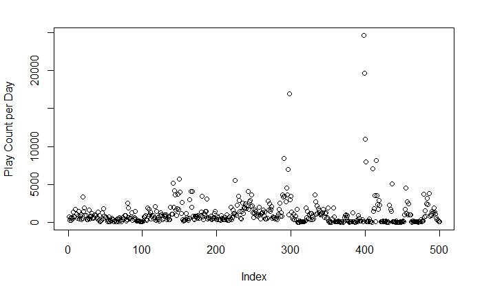

```r
plot(april.beatmaps.dataframe$playcount_per_day,
     ylab = "Play Count per Day")
```

From the plot we can see aside from a couple data points, most play_count per day do not exceed 10000. So we should perform outlier detection and take note of what data are outliers

```r
# We classify data that are three standard deviations away from mean to be outliers
april.beatmap.play.count.per.day.std.dev <- sd(april.beatmaps.dataframe$playcount_per_day)
april.beatmap.play.count.per.day.mean <- mean(april.beatmaps.dataframe$playcount_per_day)
outlier.higher.limit <- april.beatmap.play.count.per.day.mean + 3 * april.beatmap.play.count.per.day.std.dev
outlier.lower.limit <- april.beatmap.play.count.per.day.mean - 3 * april.beatmap.play.count.per.day.std.dev
high.outliers <- april.beatmaps.dataframe[april.beatmaps.dataframe$playcount_per_day > outlier.higher.limit,]
low.outliers <- april.beatmaps.dataframe[april.beatmaps.dataframe$playcount_per_day < outlier.lower.limit,]
high.outliers
```

|  | beatmapset_id | beatmap_id | approved | total_length | hit_length | version | file_md5 | diff_size | diff_overall | diff_approach | diff_drain | mode | approved_date | last_update | artist | title | creator | bpm | source | tags | genre_id | language_id | favourite_count | playcount | passcount | max_combo | difficultyrating | playcount_per_day |
| --- | --- | --- | --- | --- | --- | --- | --- | --- | --- | --- | --- | --- | --- | --- | --- | --- | --- | --- | --- | --- | --- | --- | --- | --- | --- | --- | --- | --- |
| 291 | 721804 | 1531842 | 1 | 205 | 203 | Akitoshi vs. SnowNiNo's Insane | 2f8868012beb6b7d022a22319631e29d | 4.0 | 7.5 | 9.0 | 5.0 | 0 | 2018-04-08 20:02:52 | 2018-03-31 15:23:32 | Omoi | Teo | Kroytz | 185 |  | vocaloid hatsune miku synth rock first waltz happyrocket88 dailycare morinaga snownino_ akitoshi kawashiro suzuki_1112 1112deng yales | 4 | 3 | 458 | 59184 | 11268 | 1303 | 4.540429 | 8454.857 |
| 298 | 737128 | 1556336 | 1 | 103 | 73 | Sotarks' Detonation | 10a2aa425fc1080e31e7ad152541ca2b | 4.0 | 9.0 | 9.3 | 6.0 | 0 | 2018-04-08 20:20:36 | 2018-03-31 09:42:42 | ONE OK ROCK | Bombs away | A r M i N | 160 |  | fueled by ramen oor ambitions short ver a-sketch kalibe sotarks waku jenhideo lukas [_l_u_k_a_s_] armin a_r_m_i_n tick tock hokichi | 4 | 2 | 134 | 118548 | 25146 | 346 | 5.433035 | 16935.429 |
| 398 | 757410 | 1593361 | 1 | 103 | 77 | Depression | 78f28c0528a9cff8ffbd8618bd66f2a4 | 4.0 | 8.0 | 8.5 | 6.0 | 0 | 2018-04-11 06:21:10 | 2018-04-02 23:21:51 | XXXTENTACION | SAD! | Chromoxx | 75 |  |  | 9 | 2 | 248 | 98784 | 19089 | 319 | 4.290895 | 24696.000 |
| 399 | 757410 | 1593847 | 1 | 103 | 72 | Insane | e61b4515f24c7457cb01cbe7a80b3ab8 | 3.5 | 7.0 | 8.0 | 5.5 | 0 | 2018-04-11 06:21:10 | 2018-04-02 23:21:51 | XXXTENTACION | SAD! | Chromoxx | 75 |  |  | 9 | 2 | 248 | 78687 | 11439 | 291 | 3.490982 | 19671.750 |
| 400 | 757410 | 1594554 | 1 | 103 | 72 | Hard | efcbceac2646d102b5710ef2ad41fd36 | 3.0 | 6.0 | 7.0 | 5.0 | 0 | 2018-04-11 06:21:10 | 2018-04-02 23:21:51 | XXXTENTACION | SAD! | Chromoxx | 75 |  |  | 9 | 2 | 248 | 43830 | 11781 | 264 | 2.594886 | 10957.500 |
| 401 | 757410 | 1594969 | 1 | 103 | 72 | Normal | fd7103b7ff74d71d1212a71c235c97ef | 2.5 | 4.0 | 4.5 | 4.0 | 0 | 2018-04-11 06:21:10 | 2018-04-02 23:21:51 | XXXTENTACION | SAD! | Chromoxx | 75 |  |  | 9 | 2 | 248 | 31833 | 13131 | 209 | 1.871040 | 7958.250 |
| 415 | 758344 | 1595191 | 1 | 97 | 97 | Rainbows | aa7acb13956ee91fedc1564058ed91cb | 3.8 | 9.2 | 9.4 | 5.2 | 0 | 2018-04-11 09:00:59 | 2018-04-04 02:44:41 | Colors*Slash | Colors Power ni Omakasero! | Sotarks | 200 |  | takada mitsuboshi colors op opening cut edit ver version yuuki kouno marika hioka natsumi akitoshi corinn shunao shogunmoon irohas mugiwarasekai lasse | 3 | 3 | 74 | 32553 | 5814 | 601 | 6.032940 | 8138.250 |

```r
low.outliers
```

| beatmapset_id | beatmap_id | approved | total_length | hit_length | version | file_md5 | diff_size | diff_overall | diff_approach | diff_drain | mode | approved_date | last_update | artist | title | creator | bpm | source | tags | genre_id | language_id | favourite_count | playcount | passcount | max_combo | difficultyrating | playcount_per_day |
| --- | --- | --- | --- | --- | --- | --- | --- | --- | --- | --- | --- | --- | --- | --- | --- | --- | --- | --- | --- | --- | --- | --- | --- | --- | --- | --- | --- |

From the last code block we found there are 7 data points that can be considered as high outliers and no low outliers, we should record them so when we are building model we are aware that these data points are outliers and should probably be removed from training

```r
write.csv(high.outliers,"outliers.csv")
```

We will make a new dataframe without these data points and plot it again to see if how much of a difference there are

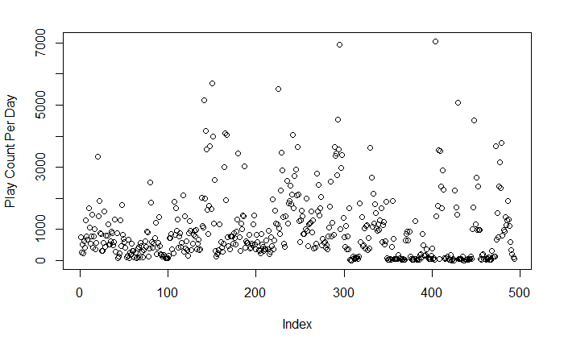

```r
april.beatmaps.dataframe.outliers.removed <- april.beatmaps.dataframe[april.beatmaps.dataframe$playcount_per_day < outlier.higher.limit,]
plot(april.beatmaps.dataframe.outliers.removed$playcount_per_day,
     ylab = "Play Count Per Day")
```

We noticed from the plots that most of data are sitting at the bottom of the graph, which prompt us to check if the data are distributed normally

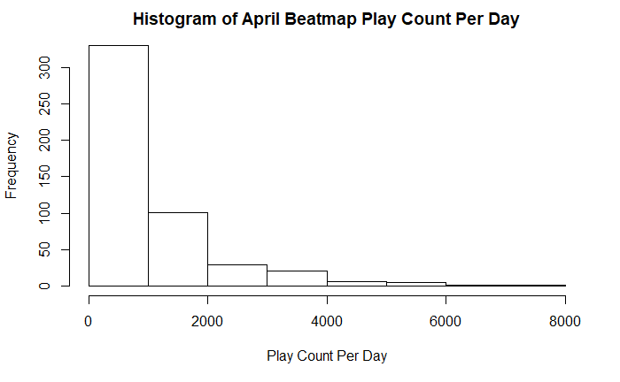

```r
hist(april.beatmaps.dataframe.outliers.removed$playcount_per_day,
     main = "Histogram of April Beatmap Play Count Per Day",
     xlab = "Play Count Per Day")
```

From the histogram we can see that our data are positively skewed. This is worth noting because it means when we are building model in the future we should consider applying a transformation to the data, or choose a model that makes no assumption of the distribution of the data

Furthermore, we also want to see if there are correlations between features to avoid collinearity. To perform a collinearity check we need to first remove the non-numeric features (and mode since it is always 0).

```r
col.to.drop <- c("version","file_md5","approved_date","last_update","artist","title","creator","source","tags","mode")
april.beatmaps.dataframe.outliers.removed.and.text.feature.removed <- april.beatmaps.dataframe.outliers.removed[, !(names(april.beatmaps.dataframe.outliers.removed) %in% col.to.drop)]
april.beatmaps.dataframe.outliers.removed.and.text.feature.removed
```

|  | beatmapset_id | beatmap_id | approved | total_length | hit_length | diff_size | diff_overall | diff_approach | diff_drain | bpm | genre_id | language_id | favourite_count | playcount | passcount | max_combo | difficultyrating | playcount_per_day |
| --- | --- | --- | --- | --- | --- | --- | --- | --- | --- | --- | --- | --- | --- | --- | --- | --- | --- | --- |
| 1 | 477006 | 1018937 | 1 | 87 | 84 | 4.5 | 9.0 | 9.0 | 6.0 | 172.000 | 3 | 6 | 27 | 10368 | 1116 | 436 | 5.267045 | 740.57143 |
| 2 | 477006 | 1019069 | 1 | 85 | 81 | 3.0 | 2.0 | 3.0 | 2.0 | 172.000 | 3 | 6 | 27 | 3393 | 1530 | 235 | 1.368581 | 242.35714 |
| 3 | 477006 | 1019973 | 1 | 87 | 84 | 4.3 | 8.0 | 8.0 | 6.0 | 172.000 | 3 | 6 | 27 | 7128 | 477 | 400 | 4.213146 | 509.14286 |
| 4 | 477006 | 1019974 | 1 | 87 | 84 | 4.0 | 4.0 | 5.0 | 3.0 | 172.000 | 3 | 6 | 27 | 3258 | 1287 | 276 | 1.885514 | 232.71429 |
| 5 | 477006 | 1020830 | 1 | 87 | 84 | 4.0 | 6.0 | 7.0 | 5.0 | 172.000 | 3 | 6 | 27 | 8766 | 2268 | 342 | 3.024783 | 626.14286 |
| 6 | 722797 | 1525815 | 1 | 85 | 80 | 2.5 | 3.0 | 3.0 | 3.0 | 180.000 | 2 | 3 | 72 | 5841 | 2484 | 236 | 1.511059 | 417.21429 |
| 7 | 722797 | 1525816 | 1 | 86 | 81 | 4.0 | 6.0 | 8.0 | 5.0 | 180.000 | 2 | 3 | 72 | 18207 | 5562 | 431 | 3.127344 | 1300.50000 |
| 8 | 722797 | 1525817 | 1 | 86 | 85 | 3.8 | 7.0 | 9.0 | 6.0 | 180.000 | 2 | 3 | 72 | 10917 | 1350 | 486 | 4.989524 | 779.78571 |
| 9 | 722797 | 1525818 | 1 | 85 | 80 | 3.0 | 4.0 | 5.0 | 4.0 | 180.000 | 2 | 3 | 72 | 9216 | 4257 | 292 | 2.136102 | 658.28571 |
| 10 | 722797 | 1526255 | 1 | 86 | 82 | 4.0 | 7.0 | 9.0 | 6.0 | 180.000 | 2 | 3 | 72 | 23571 | 3168 | 489 | 4.509651 | 1683.64286 |

[output cut: 483 more lines]

Now we can perform collinearity detection using the package

[output not shown]

[output cut: 269 more lines]

[output not shown]

[figure not shown]

```r
ggpairs(april.beatmaps.dataframe.outliers.removed.and.text.feature.removed)
```

Even though the diagram is a bit small, we can spot that there is a very strong correlation between total_length and hit_length. Using domain knowledge, we also suspect that there is a correlation between playcount and passcount, and a correlation between playcount and favoritecount. To confirm our suspicion:

```r
cor(april.beatmaps.dataframe.outliers.removed.and.text.feature.removed$total_length, april.beatmaps.dataframe.outliers.removed.and.text.feature.removed$hit_length)
```

```
[1] 0.9919622
```

```r
cor(april.beatmaps.dataframe.outliers.removed.and.text.feature.removed$playcount, april.beatmaps.dataframe.outliers.removed.and.text.feature.removed$passcount)
```

```
[1] 0.816412
```

```r
cor(april.beatmaps.dataframe.outliers.removed.and.text.feature.removed$playcount,
    april.beatmaps.dataframe.outliers.removed.and.text.feature.removed$favourite_count)
```

```
[1] 0.4613459
```

This means in the future we should probably only use one of “total_length” or “hit_length” to build our model to avoid collinearity. We should also take out passcount because it has a pretty strong correlation with playcount and our predicting variable playcount per day is an direct derivation of play count.